# DreamLeague Season 14 DPC EU & CIS Upper Division

Conner ‘Mathmagician10’ Chapman

# Introduction

Hey guys, I’m [Mathmagician10](https://www.twitch.tv/mathmagician10). I am an amateur caster who is looking to use my statistics degree for more than just my day job, so I created this team analysis in [R](https://www.rstudio.com/) with what feels like a million datasets from [DatDota](https://www.datdota.com/). I hope you guys enjoy what you read. I’m hoping this makes the draft stage a little more fun for you guys to watch since you could have a better idea of what is coming. I’ll take any and all suggestions/criticisms as I would love to know what I can do to be better. For today’s analysis, we have the **DreamLeague Season 14 DPC EU & CIS Upper Division**

# Regional Statistics

These statistics were compiled from hero data accross all DPC Winter games in patch 7.28 from DatDota.

## Top Picks

These are the highest picked heroes regardless of win rate.

| hero_name | total_picks | pick_win_pct | top_phase |
| --- | --- | --- | --- |
| Mars | 129 | 44.96 | 1st Phase |
| Puck | 127 | 56.69 | 1st Phase |
| Void Spirit | 115 | 56.52 | 1st Phase |
| Earth Spirit | 111 | 39.64 | 1st Phase |
| Nyx Assassin | 108 | 58.33 | 1st Phase |
| Wraith King | 99 | 62.63 | 3rd Phase |
| Keeper of the Light | 94 | 53.19 | 1st Phase |
| Rubick | 84 | 42.86 | 1st Phase |
| Batrider | 83 | 51.81 | 1st Phase |
| Monkey King | 82 | 58.54 | 1st Phase |

## Top Bans

These are the highest banned heroes regardless of win rate.

| hero_name | total_bans | pick_win_pct | top_phase |
| --- | --- | --- | --- |
| Puck | 224 | 56.69 | 1st Phase |
| Nyx Assassin | 224 | 58.33 | 1st Phase |
| Batrider | 216 | 51.81 | 1st Phase |
| Lycan | 187 | 47.37 | 1st Phase |
| Beastmaster | 178 | 57.14 | 3rd Phase |
| Timbersaw | 172 | 48.89 | 3rd Phase |
| Monkey King | 167 | 58.54 | 1st Phase |
| Outworld Devourer | 162 | 50.79 | 1st Phase |
| Mars | 143 | 44.96 | 1st Phase |
| Troll Warlord | 142 | 57.58 | 3rd Phase |

## Sleeper Picks

These heroes have been picked between 30 and 90 times, and have positive win rates.

| hero_name | total_picks | pick_win_pct | top_phase |
| --- | --- | --- | --- |
| Phantom Assassin | 32 | 62.50 | 3rd Phase |
| Earthshaker | 45 | 62.22 | 1st Phase |
| Elder Titan | 46 | 60.87 | 1st Phase |
| Clockwerk | 43 | 55.81 | 1st Phase |
| Nature’s Prophet | 60 | 53.33 | 1st Phase |
| Witch Doctor | 61 | 52.46 | 1st Phase |
| Underlord | 41 | 51.22 | 3rd Phase |
| Mirana | 67 | 50.75 | 1st Phase |

## Stop Picking These Heroes

These heroes have been picked more than 60 times and have win rates less than 45%.

| hero_name | total_picks | pick_win_pct | top_phase |
| --- | --- | --- | --- |
| Tusk | 67 | 37.31 | 1st Phase |
| Grimstroke | 70 | 38.57 | 2nd Phase |
| Earth Spirit | 111 | 39.64 | 1st Phase |
| Rubick | 84 | 42.86 | 1st Phase |
| Mars | 129 | 44.96 | 1st Phase |

Back to top

# EU Tournament Statistics

Average Game Time for teams in Wins and Losses

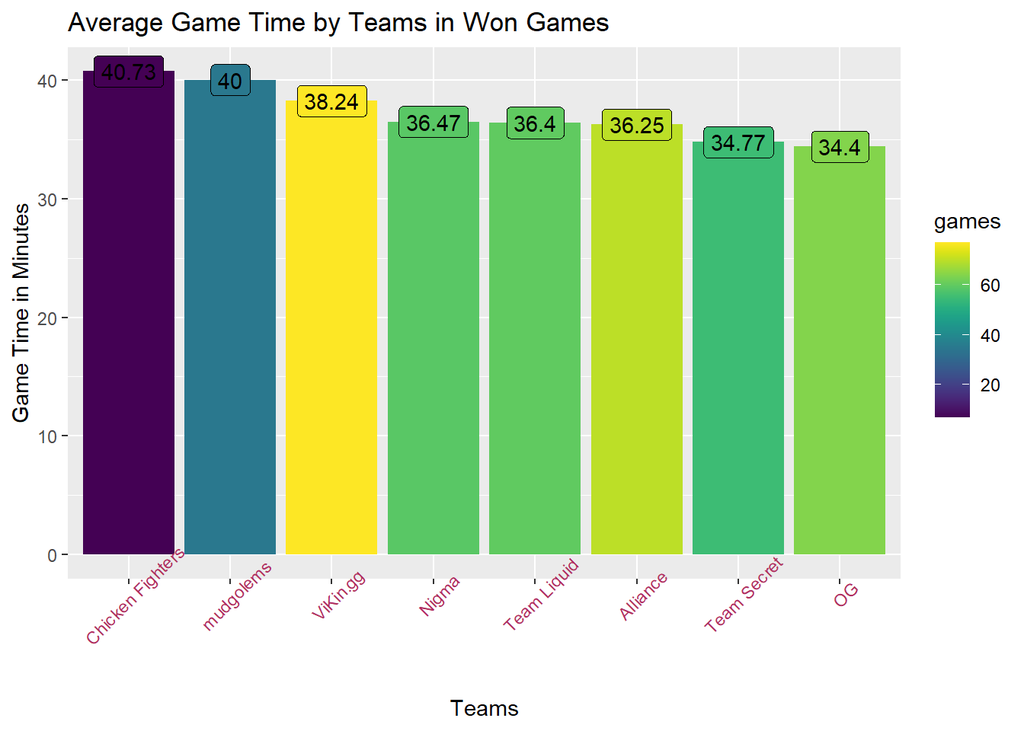

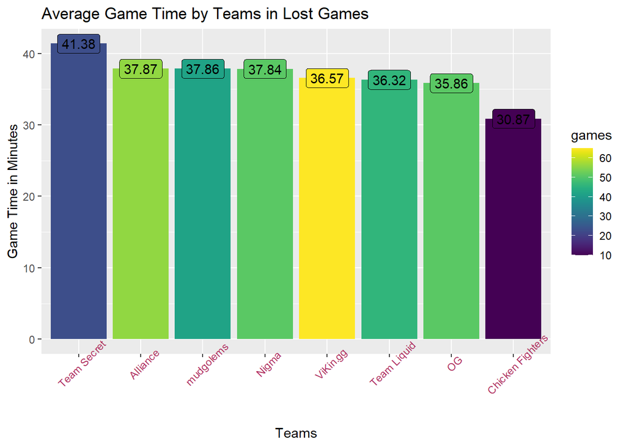

Total Draft Data for All Upper Bracket EU Teams

| hero_name | total_picks | total_bans | top_phase |
| --- | --- | --- | --- |
| Rubick | 117 | 58 | 1st Phase |
| Earth Spirit | 108 | 45 | 1st Phase |
| Io | 98 | 162 | 1st Phase |
| Faceless Void | 96 | 205 | 1st Phase |
| Phoenix | 95 | 153 | 1st Phase |
| Sven | 82 | 66 | 1st Phase |
| Tiny | 82 | 77 | 1st Phase |
| Void Spirit | 80 | 107 | 3rd Phase |
| Lina | 75 | 125 | 1st Phase |
| Slardar | 73 | 128 | 1st Phase |

# Team Statistics EU

The following data will be for all phases of the draft. The goal will be to determine what the expected picks and bans will be solely based off of statistics, not necessarily previous games or previous pick/bans. Inherently, this makes the first phase draft data the most impactful as you will likely dedicate one of your first bans to taking away high priority heroes on the other team. Typically these are not in reaction to the other bans you would have already seen.

[figure not shown]

## Team Liquid

| hero_name | total_picks | top_phase | role_type | pick_win_pct | Winrate | winrate_delta |
| --- | --- | --- | --- | --- | --- | --- |
| Earth Spirit | 27 | 1st Phase | Support | 55.56 | 47.91 | 7.65 |
| Oracle | 23 | 1st Phase | Support | 65.22 | 50.86 | 14.36 |
| Rubick | 19 | 1st Phase | Support | 52.63 | 41.67 | 10.96 |
| Void Spirit | 18 | 1st Phase | Core | 61.11 | 48.54 | 12.57 |
| Tiny | 17 | 1st Phase | Support | 52.94 | 39.06 | 13.88 |
| Lone Druid | 16 | 1st Phase | Core | 56.25 | 75.00 | -18.75 |
| Mars | 15 | 1st Phase | Support | 46.67 | 48.03 | -1.36 |
| Slardar | 15 | 1st Phase | Support | 66.67 | 50.00 | 16.67 |
| Io | 13 | 1st Phase | Support | 46.15 | 50.00 | -3.85 |
| Dark Willow | 11 | 1st Phase | Support | 54.55 | 40.91 | 13.64 |

| hero_name | Player | Total.Count | Winrate | Kills | Deaths | Assists |
| --- | --- | --- | --- | --- | --- | --- |
| Mars | Boxi | 59 | 55.93% | 5.36 | 5.17 | 13.29 |
| Centaur Warrunner | Boxi | 57 | 47.37% | 3.84 | 5.51 | 14.18 |
| Oracle | iNSaNiA | 96 | 62.50% | 2.98 | 5.24 | 13.82 |
| Keeper of the Light | iNSaNiA | 73 | 60.27% | 1.32 | 3.90 | 12.82 |
| Morphling | m’iCKe | 54 | 44.44% | 10.59 | 3.13 | 6.94 |
| Ember Spirit | m’iCKe | 38 | 55.26% | 7.97 | 3.71 | 11.92 |
| Lone Druid | Qojqva | 175 | 65.71% | 4.39 | 2.22 | 8.31 |
| Nature’s Prophet | Qojqva | 124 | 54.84% | 5.73 | 3.87 | 9.51 |
| Earth Spirit | Taiga | 91 | 52.75% | 3.66 | 6.80 | 16.14 |
| Dark Willow | Taiga | 64 | 62.50% | 5.78 | 4.88 | 13.28 |

Back to top

[figure not shown]

## OG

| hero_name | total_picks | top_phase | role_type | pick_win_pct | Winrate | winrate_delta |
| --- | --- | --- | --- | --- | --- | --- |
| Sven | 22 | 3rd Phase | Core | 86.36 | 33.33 | 53.03 |
| Earth Spirit | 20 | 1st Phase | Support | 70.00 | 47.91 | 22.09 |
| Elder Titan | 20 | 1st Phase | Support | 45.00 | 50.51 | -5.51 |
| Io | 20 | 1st Phase | Support | 70.00 | 50.00 | 20.00 |
| Magnus | 20 | 1st Phase | Core | 55.00 | 38.10 | 16.90 |
| Tusk | 17 | 2nd Phase | Support | 41.18 | 41.74 | -0.56 |
| Enigma | 15 | 3rd Phase | Support | 60.00 | 36.17 | 23.83 |
| Invoker | 15 | 1st Phase | Core | 53.33 | 48.00 | 5.33 |
| Morphling | 15 | 1st Phase | Core | 73.33 | 48.96 | 24.37 |
| Phoenix | 14 | 1st Phase | Support | 64.29 | 58.79 | 5.50 |

| hero_name | Player | Total.Count | Winrate | Kills | Deaths | Assists |
| --- | --- | --- | --- | --- | --- | --- |
| Bane | Ceb | 81 | 60.49% | 2.74 | 4.80 | 9.60 |
| Enigma | Ceb | 63 | 60.32% | 3.03 | 4.16 | 11.32 |
| Ember Spirit | midone | 104 | 70.19% | 9.21 | 3.72 | 11.49 |
| Invoker | midone | 95 | 67.37% | 8.40 | 3.98 | 11.13 |
| Io | N0tail | 161 | 72.67% | 2.93 | 5.71 | 13.01 |
| Chen | N0tail | 134 | 55.22% | 2.32 | 4.40 | 8.32 |
| Rubick | Saksa | 79 | 45.57% | 2.68 | 6.25 | 13.05 |
| Tusk | Saksa | 50 | 64.00% | 3.00 | 5.74 | 15.44 |
| Invoker | Topson | 52 | 57.69% | 6.33 | 5.50 | 12.44 |
| Monkey King | Topson | 47 | 57.45% | 9.70 | 5.87 | 9.72 |

Back to top

[figure not shown]

## Team Secret

| hero_name | total_picks | top_phase | role_type | pick_win_pct | Winrate | winrate_delta |
| --- | --- | --- | --- | --- | --- | --- |
| Rubick | 16 | 2nd Phase | Support | 68.75 | 41.67 | 27.08 |
| Drow Ranger | 13 | 1st Phase | Core | 84.62 | 44.74 | 39.88 |
| Bloodseeker | 11 | 3rd Phase | Core | 72.73 | 44.78 | 27.95 |
| Magnus | 11 | 1st Phase | Core | 81.82 | 38.10 | 43.72 |
| Nature’s Prophet | 11 | 3rd Phase | Core | 90.91 | 55.43 | 35.48 |
| Chen | 9 | 1st Phase | Support | 77.78 | 62.50 | 15.28 |
| Clockwerk | 9 | 1st Phase | Support | 100.00 | 50.51 | 49.49 |
| Ember Spirit | 9 | 3rd Phase | Core | 88.89 | 59.06 | 29.83 |
| Mars | 9 | 3rd Phase | Support | 77.78 | 48.03 | 29.75 |
| Sven | 9 | 1st Phase | Core | 66.67 | 33.33 | 33.34 |

| hero_name | Player | Total.Count | Winrate | Kills | Deaths | Assists |
| --- | --- | --- | --- | --- | --- | --- |
| Lone Druid | MATUMBAMAN | 106 | 68.87% | 5.09 | 2.47 | 8.85 |
| Gyrocopter | MATUMBAMAN | 69 | 60.87% | 8.28 | 4.07 | 10.01 |
| Morphling | Nisha | 63 | 76.19% | 9.10 | 2.19 | 7.43 |
| Kunkka | Nisha | 32 | 71.88% | 6.56 | 3.28 | 13.78 |
| Chen | Puppey | 206 | 68.45% | 2.40 | 3.14 | 10.23 |
| Enchantress | Puppey | 119 | 66.39% | 3.71 | 3.83 | 8.87 |
| Rubick | YapzOr | 224 | 65.62% | 4.12 | 3.71 | 14.42 |
| Earthshaker | YapzOr | 139 | 61.15% | 2.99 | 3.86 | 13.98 |
| Sand King | zai | 68 | 64.71% | 3.40 | 4.88 | 12.82 |
| Enigma | zai | 64 | 75.00% | 3.39 | 4.05 | 10.70 |

Back to top

[figure not shown]

## Team Nigma

| hero_name | total_picks | top_phase | role_type | pick_win_pct | Winrate | winrate_delta |
| --- | --- | --- | --- | --- | --- | --- |
| Phoenix | 35 | 1st Phase | Support | 60.00 | 58.79 | 1.21 |
| Rubick | 24 | 1st Phase | Support | 66.67 | 41.67 | 25.00 |
| Batrider | 20 | 1st Phase | Core | 50.00 | 55.88 | -5.88 |
| Magnus | 20 | 1st Phase | Core | 55.00 | 38.10 | 16.90 |
| Vengeful Spirit | 17 | 1st Phase | Support | 70.59 | 45.16 | 25.43 |
| Faceless Void | 15 | 1st Phase | Core | 73.33 | 38.89 | 34.44 |
| Death Prophet | 13 | 1st Phase | Core | 76.92 | 45.00 | 31.92 |
| Slardar | 13 | 3rd Phase | Support | 69.23 | 50.00 | 19.23 |
| Clockwerk | 12 | 2nd Phase | Support | 66.67 | 50.51 | 16.16 |
| Void Spirit | 12 | 3rd Phase | Core | 50.00 | 48.54 | 1.46 |

| hero_name | Player | Total.Count | Winrate | Kills | Deaths | Assists |
| --- | --- | --- | --- | --- | --- | --- |
| Rubick | GH | 90 | 64.44% | 3.04 | 5.49 | 15.21 |
| Io | GH | 90 | 70.00% | 2.14 | 5.48 | 15.61 |
| Rubick | KuroKy | 228 | 64.04% | 3.34 | 4.96 | 11.08 |
| Chen | KuroKy | 95 | 70.53% | 2.07 | 4.19 | 12.89 |
| Dark Seer | MinD ContRoL | 148 | 64.86% | 3.83 | 3.87 | 14.58 |
| Nature’s Prophet | MinD ContRoL | 95 | 62.11% | 5.74 | 4.99 | 12.98 |
| Invoker | Miracle- | 87 | 65.52% | 10.08 | 3.99 | 9.16 |
| Ember Spirit | Miracle- | 72 | 65.28% | 10.75 | 4.39 | 11.61 |
| Invoker | W33 | 102 | 55.88% | 7.03 | 3.93 | 9.25 |
| Lina | W33 | 66 | 50.00% | 7.89 | 5.71 | 7.39 |

Back to top

[figure not shown]

## Vikin.GG

| hero_name | total_picks | top_phase | role_type | pick_win_pct | Winrate | winrate_delta |
| --- | --- | --- | --- | --- | --- | --- |
| Enchantress | 31 | 1st Phase | Support | 54.84 | 53.12 | 1.72 |
| Io | 29 | 1st Phase | Support | 51.72 | 50.00 | 1.72 |
| Slardar | 28 | 1st Phase | Support | 67.86 | 50.00 | 17.86 |
| Lina | 24 | 1st Phase | Core | 66.67 | 52.78 | 13.89 |
| Snapfire | 23 | 2nd Phase | Support | 52.17 | 53.66 | -1.49 |
| Tiny | 23 | 1st Phase | Support | 56.52 | 39.06 | 17.46 |
| Vengeful Spirit | 22 | 1st Phase | Support | 63.64 | 45.16 | 18.48 |
| Faceless Void | 21 | 1st Phase | Core | 61.90 | 38.89 | 23.01 |
| Bloodseeker | 20 | 3rd Phase | Core | 60.00 | 44.78 | 15.22 |
| Rubick | 20 | 1st Phase | Support | 65.00 | 41.67 | 23.33 |

| hero_name | Player | Total.Count | Winrate | Kills | Deaths | Assists |
| --- | --- | --- | --- | --- | --- | --- |
| Rubick | Aramis | 39 | 51.28% | 2.92 | 5.82 | 12.92 |
| Shadow Demon | Aramis | 23 | 60.87% | 3.22 | 6.04 | 10.13 |
| Ember Spirit | BOOM | 30 | 63.33% | 7.47 | 3.33 | 12.63 |
| Storm Spirit | BOOM | 23 | 56.52% | 9.70 | 3.78 | 9.39 |
| Enchantress | Seleri | 54 | 59.26% | 3.96 | 5.07 | 11.94 |
| Vengeful Spirit | Seleri | 33 | 60.61% | 1.79 | 8.24 | 15.76 |
| Faceless Void | Shad | 24 | 58.33% | 7.12 | 2.58 | 9.42 |
| Spectre | Shad | 23 | 60.87% | 7.61 | 2.43 | 12.43 |
| Beastmaster | Tobi | 31 | 58.06% | 3.71 | 5.19 | 14.29 |
| Slardar | Tobi | 27 | 66.67% | 3.74 | 5.22 | 11.41 |

Back to top

[figure not shown]

## Alliance

| hero_name | total_picks | top_phase | role_type | pick_win_pct | Winrate | winrate_delta |
| --- | --- | --- | --- | --- | --- | --- |
| Rubick | 22 | 1st Phase | Support | 50.00 | 41.67 | 8.33 |
| Earth Spirit | 18 | 1st Phase | Support | 44.44 | 47.91 | -3.47 |
| Jakiro | 18 | 2nd Phase | Support | 44.44 | 39.13 | 5.31 |
| Nature’s Prophet | 18 | 3rd Phase | Core | 77.78 | 55.43 | 22.35 |
| Death Prophet | 17 | 3rd Phase | Core | 47.06 | 45.00 | 2.06 |
| Faceless Void | 16 | 1st Phase | Core | 81.25 | 38.89 | 42.36 |
| Lina | 16 | 1st Phase | Core | 43.75 | 52.78 | -9.03 |
| Timbersaw | 16 | 3rd Phase | Core | 75.00 | 49.40 | 25.60 |
| Mars | 15 | 1st Phase | Support | 60.00 | 48.03 | 11.97 |
| Clockwerk | 14 | 1st Phase | Support | 85.71 | 50.51 | 35.20 |

| hero_name | Player | Total.Count | Winrate | Kills | Deaths | Assists |
| --- | --- | --- | --- | --- | --- | --- |
| Vengeful Spirit | Fng | 112 | 58.93% | 2.19 | 7.16 | 12.82 |
| Bane | Fng | 103 | 56.31% | 2.61 | 6.42 | 12.11 |
| Io | Handsken | 107 | 50.47% | 2.21 | 6.13 | 10.87 |
| Disruptor | Handsken | 92 | 53.26% | 2.95 | 5.82 | 14.00 |
| Puck | Limmp | 116 | 55.17% | 6.19 | 3.54 | 11.67 |
| Death Prophet | Limmp | 99 | 56.57% | 6.70 | 3.38 | 9.66 |
| Morphling | Nikobaby | 50 | 44.00% | 9.98 | 2.98 | 6.58 |
| Faceless Void | Nikobaby | 48 | 66.67% | 9.21 | 1.92 | 10.50 |
| Puck | S4 | 192 | 67.19% | 5.39 | 4.33 | 11.94 |
| Batrider | S4 | 178 | 59.55% | 5.03 | 4.81 | 11.34 |

Back to top

[figure not shown]

## Tundra Esports

| hero_name | total_picks | top_phase | role_type | pick_win_pct | Winrate | winrate_delta |
| --- | --- | --- | --- | --- | --- | --- |
| Void Spirit | 24 | 3rd Phase | Core | 58.33 | 48.54 | 9.79 |
| Faceless Void | 20 | 1st Phase | Core | 60.00 | 38.89 | 21.11 |
| Mirana | 15 | 3rd Phase | Support | 46.67 | 51.83 | -5.16 |
| Viper | 15 | 3rd Phase | Support | 60.00 | 42.68 | 17.32 |
| Enchantress | 14 | 1st Phase | Support | 50.00 | 53.12 | -3.12 |
| Io | 13 | 1st Phase | Support | 38.46 | 50.00 | -11.54 |
| Snapfire | 13 | 1st Phase | Support | 46.15 | 53.66 | -7.51 |
| Earth Spirit | 12 | 3rd Phase | Support | 66.67 | 47.91 | 18.76 |
| Sven | 12 | 1st Phase | Core | 41.67 | 33.33 | 8.34 |
| Phoenix | 11 | 2nd Phase | Support | 36.36 | 58.79 | -22.43 |

| hero_name | Player | Total.Count | Winrate | Kills | Deaths | Assists |
| --- | --- | --- | --- | --- | --- | --- |
| Beastmaster | 33 | 56 | 55.36% | 3.41 | 4.27 | 11.30 |
| Sand King | 33 | 54 | 51.85% | 3.83 | 5.44 | 11.35 |
| Rubick | Biver | 58 | 41.38% | 2.41 | 5.88 | 12.69 |
| Earth Spirit | Biver | 35 | 65.71% | 3.74 | 5.46 | 18.43 |
| Puck | Fata | 220 | 60.45% | 6.17 | 4.13 | 10.59 |
| Razor | Fata | 104 | 59.62% | 6.59 | 3.92 | 8.69 |
| Ember Spirit | Nine | 18 | 55.56% | 7.72 | 4.44 | 12.22 |
| Shadow Fiend | Nine | 17 | 35.29% | 6.29 | 5.53 | 9.59 |
| Lifestealer | Oliver | 70 | 54.29% | 7.11 | 3.03 | 9.50 |
| Faceless Void | Oliver | 43 | 60.47% | 7.67 | 2.77 | 9.77 |

Back to top

[figure not shown]

## High Coast Esports

| hero_name | total_picks | top_phase | role_type | pick_win_pct | Winrate | winrate_delta |
| --- | --- | --- | --- | --- | --- | --- |
| Shadow Demon | 5 | 1st Phase | Support | 80.00 | 56.63 | 23.37 |
| Mars | 4 | 1st Phase | Support | 75.00 | 48.03 | 26.97 |
| Nyx Assassin | 4 | 1st Phase | Support | 25.00 | 58.93 | -33.93 |
| Puck | 4 | 3rd Phase | Core | 0.00 | 55.61 | -55.61 |
| Skywrath Mage | 4 | 3rd Phase | Support | 75.00 | 55.00 | 20.00 |
| Earth Spirit | 3 | 1st Phase | Support | 33.33 | 47.91 | -14.58 |
| Ember Spirit | 3 | 3rd Phase | Core | 66.67 | 59.06 | 7.61 |
| Invoker | 3 | 3rd Phase | Core | 100.00 | 48.00 | 52.00 |
| Io | 3 | 1st Phase | Support | 0.00 | 50.00 | -50.00 |
| Lina | 3 | 1st Phase | Core | 33.33 | 52.78 | -19.45 |

| hero_name | Player | Total.Count | Winrate | Kills | Deaths | Assists |
| --- | --- | --- | --- | --- | --- | --- |
| Terrorblade | CharlieDota | 29 | 62.07% | 7.72 | 2.93 | 8.14 |
| Faceless Void | CharlieDota | 25 | 52.00% | 6.96 | 3.00 | 9.56 |
| Tiny | Chessie | 40 | 52.50% | 8.72 | 3.90 | 8.53 |
| Nature’s Prophet | Chessie | 40 | 50.00% | 6.35 | 4.58 | 12.12 |
| Lifestealer | Era | 143 | 64.34% | 7.57 | 2.33 | 7.99 |
| Tiny | Era | 127 | 62.20% | 8.53 | 3.42 | 8.56 |
| Invoker | Supream^ | 29 | 55.17% | 8.69 | 4.34 | 12.07 |
| Morphling | Supream^ | 26 | 23.08% | 5.50 | 4.27 | 5.08 |
| Beastmaster | Xibbe | 20 | 45.00% | 4.50 | 5.45 | 12.60 |
| Mars | Xibbe | 18 | 66.67% | 4.67 | 5.33 | 14.11 |

Back to top

# CIS Tournament Statistics

Average Game Time for teams in Wins and Losses

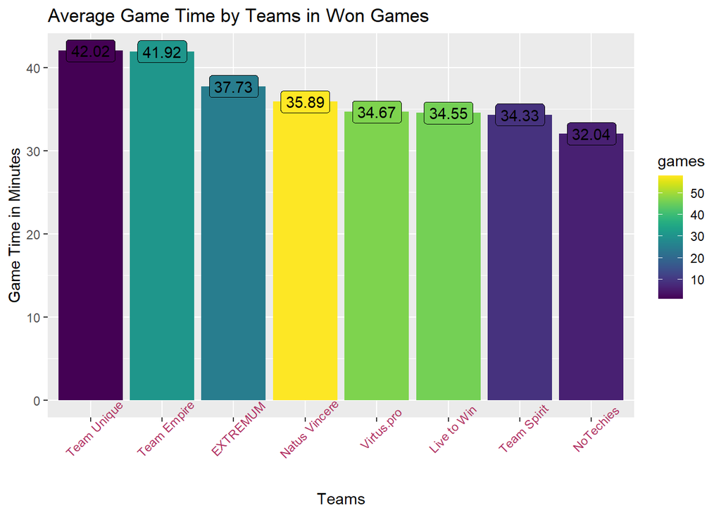

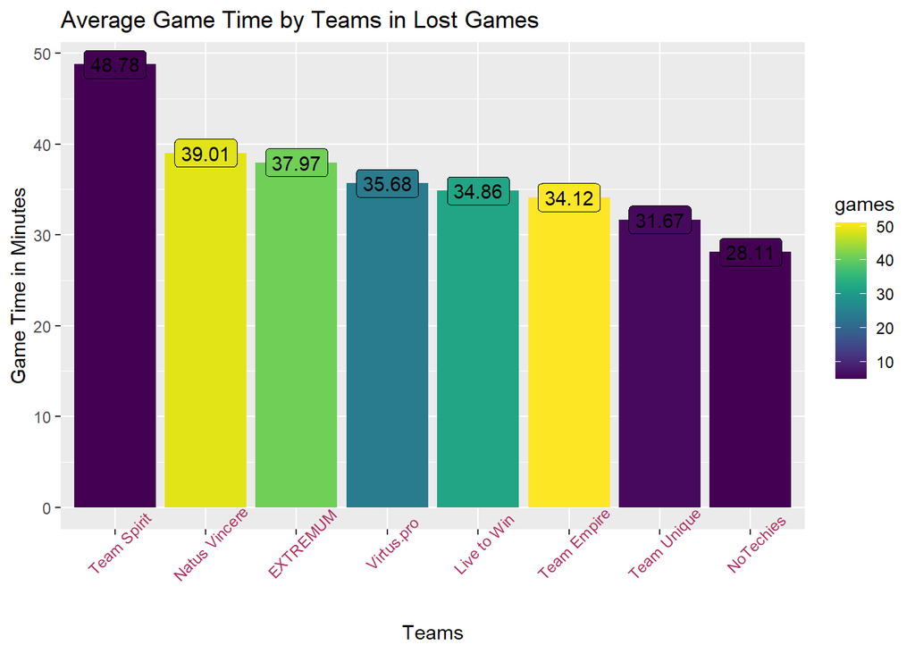

| hero_name | total_picks | total_bans | top_phase |
| --- | --- | --- | --- |
| Phoenix | 78 | 81 | 1st Phase |
| Void Spirit | 73 | 57 | 3rd Phase |
| Lina | 69 | 59 | 1st Phase |
| Mars | 53 | 65 | 1st Phase |
| Faceless Void | 50 | 75 | 1st Phase |
| Ember Spirit | 46 | 38 | 3rd Phase |
| Rubick | 46 | 44 | 3rd Phase |
| Clockwerk | 45 | 24 | 1st Phase |
| Storm Spirit | 44 | 63 | 3rd Phase |
| Oracle | 42 | 37 | 1st Phase |

# Team Statistics CIS

The following data will be for all phases of the draft. The goal will be to determine what the expected picks and bans will be solely based off of statistics, not necessarily previous games or previous pick/bans. Inherently, this makes the first phase draft data the most impactful as you will likely dedicate one of your first bans to taking away high priority heroes on the other team. Typically these are not in reaction to the other bans you would have already seen.

[figure not shown]

## Virtus.pro

| hero_name | total_picks | top_phase | role_type | pick_win_pct | Winrate | winrate_delta |
| --- | --- | --- | --- | --- | --- | --- |
| Faceless Void | 15 | 1st Phase | Core | 66.67 | 38.89 | 27.78 |
| Lina | 12 | 1st Phase | Core | 75.00 | 52.78 | 22.22 |
| Viper | 12 | 1st Phase | Support | 75.00 | 42.68 | 32.32 |
| Enchantress | 11 | 1st Phase | Support | 45.45 | 53.12 | -7.67 |
| Phoenix | 11 | 1st Phase | Support | 45.45 | 58.79 | -13.34 |
| Shadow Demon | 11 | 1st Phase | Support | 72.73 | 56.63 | 16.10 |
| Tiny | 10 | 1st Phase | Support | 60.00 | 39.06 | 20.94 |
| Mars | 9 | 1st Phase | Support | 66.67 | 48.03 | 18.64 |
| Phantom Assassin | 8 | 1st Phase | Core | 62.50 | 48.94 | 13.56 |
| Sven | 8 | 1st Phase | Core | 50.00 | 33.33 | 16.67 |

| hero_name | Player | Total.Count | Winrate | Kills | Deaths | Assists |
| --- | --- | --- | --- | --- | --- | --- |
| Sand King | DM | 24 | 62.50% | 3.71 | 5.38 | 15.29 |
| Axe | DM | 21 | 57.14% | 5.00 | 5.62 | 11.14 |
| Ember Spirit | Gpk | 27 | 59.26% | 7.22 | 2.52 | 10.78 |
| Storm Spirit | Gpk | 24 | 29.17% | 6.83 | 3.08 | 9.25 |
| Disruptor | Kingslayer | 28 | 67.86% | 2.50 | 4.43 | 14.54 |
| Oracle | Kingslayer | 24 | 41.67% | 3.21 | 4.29 | 12.46 |
| Phantom Lancer | Nightfall | 23 | 82.61% | 8.83 | 1.70 | 8.61 |
| Faceless Void | Nightfall | 22 | 77.27% | 8.45 | 1.64 | 11.77 |
| Rubick | Save- | 40 | 60.00% | 2.15 | 3.83 | 11.80 |
| Phoenix | Save- | 24 | 70.83% | 3.75 | 4.83 | 17.04 |

Back to top

[figure not shown]

## Natus Vincere

| hero_name | total_picks | top_phase | role_type | pick_win_pct | Winrate | winrate_delta |
| --- | --- | --- | --- | --- | --- | --- |
| Phoenix | 27 | 1st Phase | Support | 66.67 | 58.79 | 7.88 |
| Lina | 26 | 1st Phase | Core | 57.69 | 52.78 | 4.91 |
| Doom | 23 | 1st Phase | Core | 65.22 | 60.61 | 4.61 |
| Oracle | 22 | 1st Phase | Support | 45.45 | 50.86 | -5.41 |
| Rubick | 20 | 1st Phase | Support | 60.00 | 41.67 | 18.33 |
| Mars | 19 | 1st Phase | Support | 63.16 | 48.03 | 15.13 |
| Chen | 17 | 1st Phase | Support | 94.12 | 62.50 | 31.62 |
| Drow Ranger | 16 | 3rd Phase | Core | 62.50 | 44.74 | 17.76 |
| Spectre | 16 | 1st Phase | Core | 62.50 | 27.78 | 34.72 |
| Void Spirit | 16 | 3rd Phase | Core | 50.00 | 48.54 | 1.46 |

| hero_name | Player | Total.Count | Winrate | Kills | Deaths | Assists |
| --- | --- | --- | --- | --- | --- | --- |
| Ancient Apparition | ALWAYSWANNAFLY | 118 | 63.56% | 3.20 | 5.86 | 11.92 |
| Bane | ALWAYSWANNAFLY | 94 | 52.13% | 2.85 | 6.31 | 9.46 |
| Batrider | GeneRaL | 109 | 55.05% | 4.53 | 5.36 | 12.82 |
| Beastmaster | GeneRaL | 88 | 61.36% | 4.36 | 5.09 | 11.01 |
| Invoker | Iceberg | 66 | 51.52% | 7.52 | 4.62 | 9.55 |
| Outworld Devourer | Iceberg | 55 | 56.36% | 8.36 | 3.91 | 6.60 |
| Chen | RodjER | 56 | 67.86% | 2.36 | 4.02 | 12.30 |
| Earthshaker | RodjER | 50 | 64.00% | 2.30 | 6.18 | 13.64 |
| Phantom Lancer | V-Tune | 46 | 58.70% | 7.50 | 1.98 | 7.78 |
| Lifestealer | V-Tune | 37 | 64.86% | 7.78 | 1.89 | 8.54 |

Back to top

[figure not shown]

## Live to Win

| hero_name | total_picks | top_phase | role_type | pick_win_pct | Winrate | winrate_delta |
| --- | --- | --- | --- | --- | --- | --- |
| Nature’s Prophet | 15 | 1st Phase | Core | 86.67 | 55.43 | 31.24 |
| Lina | 14 | 1st Phase | Core | 42.86 | 52.78 | -9.92 |
| Sven | 14 | 1st Phase | Core | 57.14 | 33.33 | 23.81 |
| Faceless Void | 13 | 1st Phase | Core | 69.23 | 38.89 | 30.34 |
| Snapfire | 13 | 1st Phase | Support | 69.23 | 53.66 | 15.57 |
| Ember Spirit | 11 | 3rd Phase | Core | 72.73 | 59.06 | 13.67 |
| Invoker | 11 | 3rd Phase | Core | 63.64 | 48.00 | 15.64 |
| Phoenix | 11 | 2nd Phase | Support | 63.64 | 58.79 | 4.85 |
| Slardar | 11 | 1st Phase | Support | 45.45 | 50.00 | -4.55 |
| Earth Spirit | 9 | 1st Phase | Support | 55.56 | 47.91 | 7.65 |

| hero_name | Player | Total.Count | Winrate | Kills | Deaths | Assists |
| --- | --- | --- | --- | --- | --- | --- |
| Legion Commander | AfterLife | 70 | 65.71% | 4.33 | 4.07 | 10.73 |
| Dark Seer | AfterLife | 66 | 48.48% | 3.59 | 4.00 | 13.38 |
| Faceless Void | Dream’ | 38 | 71.05% | 7.87 | 2.63 | 11.76 |
| Morphling | Dream’ | 34 | 47.06% | 8.50 | 3.09 | 6.32 |
| Queen of Pain | Fn | 42 | 45.24% | 8.90 | 3.10 | 9.17 |
| Ember Spirit | Fn | 40 | 55.00% | 8.22 | 3.30 | 10.50 |
| Earth Spirit | Immersion | 84 | 60.71% | 3.42 | 5.75 | 15.69 |
| Nyx Assassin | Immersion | 39 | 61.54% | 1.77 | 7.05 | 12.51 |
| Io | SoNNeikO | 105 | 60.00% | 3.95 | 6.59 | 14.41 |
| Disruptor | SoNNeikO | 84 | 58.33% | 2.83 | 6.18 | 14.01 |

Back to top

[figure not shown]

## Team Spirit

| hero_name | total_picks | top_phase | role_type | pick_win_pct | Winrate | winrate_delta |
| --- | --- | --- | --- | --- | --- | --- |
| Void Spirit | 5 | 1st Phase | Core | 80.00 | 48.54 | 31.46 |
| Crystal Maiden | 4 | 2nd Phase | Support | 25.00 | 41.84 | -16.84 |
| Disruptor | 4 | 2nd Phase | Support | 75.00 | 68.42 | 6.58 |
| Phoenix | 4 | 1st Phase | Support | 75.00 | 58.79 | 16.21 |
| Batrider | 3 | 3rd Phase | Core | 66.67 | 55.88 | 10.79 |
| Death Prophet | 3 | 3rd Phase | Core | 66.67 | 45.00 | 21.67 |
| Nyx Assassin | 3 | 1st Phase | Support | 66.67 | 58.93 | 7.74 |
| Ursa | 3 | 3rd Phase | Core | 66.67 | 43.37 | 23.30 |
| Anti-Mage | 2 | 3rd Phase | Core | 50.00 | 45.00 | 5.00 |
| Axe | 2 | 3rd Phase | Support | 50.00 | 37.50 | 12.50 |

| hero_name | Player | Total.Count | Winrate | Kills | Deaths | Assists |
| --- | --- | --- | --- | --- | --- | --- |
| Mars | Collapse | 29 | 55.17% | 6.34 | 4.45 | 10.55 |
| Axe | Collapse | 8 | 50.00% | 8.25 | 5.62 | 7.50 |
| Disruptor | Miposhka | 94 | 56.38% | 2.19 | 6.11 | 15.69 |
| Earth Spirit | Miposhka | 67 | 55.22% | 2.84 | 6.12 | 16.24 |
| Phoenix | So bad | 32 | 71.88% | 2.78 | 4.53 | 14.50 |
| Rubick | So bad | 27 | 48.15% | 2.48 | 5.74 | 12.41 |
| Invoker | TORONTOTOKYO | 10 | 90.00% | 6.80 | 2.80 | 14.00 |
| Void Spirit | TORONTOTOKYO | 9 | 77.78% | 6.00 | 1.44 | 8.78 |
| Faceless Void | Yatoro | 15 | 73.33% | 7.00 | 3.80 | 12.67 |
| Drow Ranger | Yatoro | 14 | 64.29% | 7.36 | 4.07 | 8.43 |

Back to top

[figure not shown]

## Extremum

| hero_name | total_picks | top_phase | role_type | pick_win_pct | Winrate | winrate_delta |
| --- | --- | --- | --- | --- | --- | --- |
| Void Spirit | 19 | 3rd Phase | Core | 52.63 | 48.54 | 4.09 |
| Grimstroke | 11 | 1st Phase | Support | 36.36 | 37.86 | -1.50 |
| Storm Spirit | 11 | 3rd Phase | Core | 36.36 | 54.84 | -18.48 |
| Vengeful Spirit | 10 | 1st Phase | Support | 30.00 | 45.16 | -15.16 |
| Ember Spirit | 9 | 3rd Phase | Core | 66.67 | 59.06 | 7.61 |
| Medusa | 9 | 3rd Phase | Core | 44.44 | 60.78 | -16.34 |
| Mars | 8 | 1st Phase | Support | 50.00 | 48.03 | 1.97 |
| Phoenix | 8 | 1st Phase | Support | 25.00 | 58.79 | -33.79 |
| Rubick | 8 | 1st Phase | Support | 37.50 | 41.67 | -4.17 |
| Beastmaster | 7 | 3rd Phase | Support | 57.14 | 57.39 | -0.25 |

| hero_name | Player | Total.Count | Winrate | Kills | Deaths | Assists |
| --- | --- | --- | --- | --- | --- | --- |
| Shadow Shaman | Chuvash | 27 | 48.15% | 2.70 | 6.37 | 12.00 |
| Tiny | Chuvash | 25 | 52.00% | 3.80 | 5.28 | 11.88 |
| Queen of Pain | G | 109 | 54.13% | 9.82 | 3.92 | 7.70 |
| Shadow Fiend | G | 109 | 55.96% | 7.75 | 4.07 | 8.29 |
| Ember Spirit | Mellojul | 15 | 66.67% | 9.80 | 3.33 | 12.87 |
| Storm Spirit | Mellojul | 14 | 35.71% | 7.14 | 4.64 | 10.21 |
| Faceless Void | Nefrit | 16 | 31.25% | 5.88 | 3.94 | 11.56 |
| Troll Warlord | Nefrit | 11 | 54.55% | 8.27 | 3.55 | 9.09 |
| Batrider | Shachlo | 59 | 49.15% | 3.58 | 4.39 | 12.12 |
| Axe | Shachlo | 49 | 51.02% | 7.14 | 5.27 | 7.06 |

Back to top

[figure not shown]

## Team Empire

| hero_name | total_picks | top_phase | role_type | pick_win_pct | Winrate | winrate_delta |
| --- | --- | --- | --- | --- | --- | --- |
| Phoenix | 17 | 1st Phase | Support | 41.18 | 58.79 | -17.61 |
| Void Spirit | 16 | 2nd Phase | Core | 50.00 | 48.54 | 1.46 |
| Clockwerk | 15 | 1st Phase | Support | 40.00 | 50.51 | -10.51 |
| Faceless Void | 15 | 1st Phase | Core | 33.33 | 38.89 | -5.56 |
| Lina | 12 | 3rd Phase | Core | 58.33 | 52.78 | 5.55 |
| Tiny | 11 | 1st Phase | Support | 36.36 | 39.06 | -2.70 |
| Snapfire | 10 | 1st Phase | Support | 40.00 | 53.66 | -13.66 |
| Beastmaster | 9 | 3rd Phase | Support | 33.33 | 57.39 | -24.06 |
| Enchantress | 9 | 1st Phase | Support | 33.33 | 53.12 | -19.79 |
| Invoker | 9 | 3rd Phase | Core | 44.44 | 48.00 | -3.56 |

[output not shown]

Back to top

[figure not shown]

## NoTechies

| hero_name | total_picks | top_phase | role_type | pick_win_pct | Winrate | winrate_delta |
| --- | --- | --- | --- | --- | --- | --- |
| Puck | 4 | 1st Phase | Core | 0 | 55.61 | -55.61 |
| Bloodseeker | 2 | 3rd Phase | Core | 0 | 44.78 | -44.78 |
| Crystal Maiden | 2 | 2nd Phase | Support | 50 | 41.84 | 8.16 |
| Death Prophet | 2 | 3rd Phase | Core | 0 | 45.00 | -45.00 |
| Shadow Shaman | 2 | 1st Phase | Support | 50 | 48.76 | 1.24 |
| Anti-Mage | 1 | 3rd Phase | Core | 0 | 45.00 | -45.00 |
| Chaos Knight | 1 | 3rd Phase | Core | 0 | 61.11 | -61.11 |
| Doom | 1 | 3rd Phase | Core | 0 | 60.61 | -60.61 |
| Earth Spirit | 1 | 1st Phase | Support | 0 | 47.91 | -47.91 |
| Enigma | 1 | 3rd Phase | Support | 0 | 36.17 | -36.17 |

| hero_name | Player | Total.Count | Winrate | Kills | Deaths | Assists |
| --- | --- | --- | --- | --- | --- | --- |
| Lifestealer | Crystallize | 41 | 46.34% | 6.24 | 2.56 | 7.76 |
| Faceless Void | Crystallize | 37 | 56.76% | 6.16 | 3.41 | 11.16 |
| Invoker | Ergon | 15 | 53.33% | 4.27 | 3.73 | 8.73 |
| Lina | Ergon | 15 | 66.67% | 7.33 | 2.60 | 7.27 |
| Mars | Malik | 12 | 25.00% | 3.83 | 6.25 | 11.33 |
| Beastmaster | Malik | 10 | 50.00% | 3.40 | 5.20 | 10.90 |
| Disruptor | Solo | 138 | 65.94% | 2.70 | 6.35 | 15.22 |
| Shadow Demon | Solo | 81 | 74.07% | 2.78 | 6.64 | 12.49 |
| Earth Spirit | Zayac | 61 | 54.10% | 3.11 | 6.11 | 14.75 |
| Shadow Demon | Zayac | 47 | 68.09% | 3.91 | 5.81 | 11.79 |

Back to top

[figure not shown]

## Team Unique

[output not shown]

| hero_name | Player | Total.Count | Winrate | Kills | Deaths | Assists |
| --- | --- | --- | --- | --- | --- | --- |
| Rubick | Bignum | 51 | 39.22% | 2.96 | 5.14 | 12.51 |
| Earth Spirit | Bignum | 41 | 43.90% | 3.02 | 5.39 | 13.88 |
| Disruptor | CemaTheSlayeR | 119 | 58.82% | 2.80 | 4.93 | 13.50 |
| Rubick | CemaTheSlayeR | 110 | 55.45% | 3.23 | 5.50 | 13.03 |
| Axe | Ghostik | 65 | 58.46% | 7.15 | 5.82 | 9.89 |
| Beastmaster | Ghostik | 62 | 37.10% | 3.29 | 5.08 | 9.47 |
| Lifestealer | Palantimos | 40 | 47.50% | 5.95 | 3.08 | 7.60 |
| Troll Warlord | Palantimos | 38 | 44.74% | 6.95 | 3.74 | 8.47 |
| Death Prophet | Pikachu | 29 | 41.38% | 6.21 | 4.10 | 9.24 |
| Ember Spirit | Pikachu | 25 | 44.00% | 8.00 | 4.32 | 12.48 |

Back to top

# Possible Lurking Variables

- Hero Data Pulled 02-06-2021
  - Averages have likely had marginal changes
- Draft Data Pulled 02-06-2021
  - All Draft Data Pulled for 7.27/7.28
    - Strong heroes from 7.27 have higher sample sizes than current 7.28 meta
  - Possible bias towards winrates of top teams playing weaker opponents
- Player Data Pulled for all patches
  - Likely has some pull towards current hero meta

# Shameless Plugs

[Twitch](https://www.twitch.tv/mathmagician10)

[Youtube](https://www.youtube.com/channel/UC6xKKmXc3GTvskM1oyifKig?view_as=subscriber)

[Twitter](https://www.twitter.com/mathmagician10)

[Instagram](https://www.instagram.com/mathmagician10)